# ANGSD

J. Ignacio Lucas Lledó

6/12/2021

## Becoming familiar with ANGSD

ANGSD (Nielsen 2012) can perform several analysis using genotype likelihoods, including the ABBA/BABA statistics. Because it does not require calling genotypes, the input data can be sequence data in BAM files. Alternatively, it accepts genotype likelihoods in Beagle format, and even VCF. But the ABBA/BABA test and others can only be performed from sequence files. I do not want to pass row BAM files to `angsd`, because it is unclear how it handles indels, which are abundant in our data set. I trust `freebayes` to align indels better, and that’s why I prefer to use the genotype likelihoods for only binary SNPs stored in our VCFs.

PCAngsd is a separate program in Python. Unfortunately, I was not able to install it system-wide, and I’m using below my local installation.

## Estimate allele frequencies and site-frequency spectra.

Allele frequencies can be estimated from VCF, for every site. But I don’t see the way to filter by individuals. I must create a population-specific vcf, from the original `../2021-11-16/all.vcf`, so that variable sites are a representative sample of variation in each species. Recall that the filtered VCF in `2021-12-01` required sites to be variable overall, which introduces many fixed differences among species that would bias their SFS.

ANGSD does not accept just any VCF. From what I experienced it occasionally stops at an intermediate point of a VCF when estimating allele frequencies or site-frequency spectra. This is a sign of some sites not having the expected quality or amount of data. I solved the issue by requiring genotypes to be covered at least 5 times (`--minDP 5`; maybe 4 would have been enough) and sites to have at least 1 minor allele counted (`--mac 1`).

```bash
if [ ! -e popfile.txt ]; then ./make_popfile.sh; fi
if [ ! -e lowest15.txt ]; then cp ../2021-12-01/lowest15.txt ./; fi

VCF='../2021-11-16/all.vcf'
for pop in roumanicus europaeus concolor; do
   if [ ! -e $pop.txt ]; then
      grep $pop popfile.txt | grep -v -f lowest15.txt | cut -f 1 > $pop.txt
   fi
   if [ ! -e $pop.recode.vcf ]; then
      vcftools --vcf $VCF \
               --keep $pop.txt \
               --remove-indels \
               --minQ 50 \
               --minDP 5 \
               --min-alleles 2 \
               --max-alleles 2 \
               --max-missing 0.75 \
               --mac 1 \
               --recode \
               --out $pop &> $pop.recode.log &
   fi
done
wait

for pop in roumanicus europaeus concolor; do
   if [ ! -e $pop.mafs ]; then
      angsd -vcf-gl $pop.recode.vcf \
            -fai ../../data/reference.fa.fai \
            -doMaf 1 -doMajorMinor 1 -out $pop &> $pop.mafs.log
      gunzip $pop.mafs.gz
   fi
   if [ ! -e $pop.sfs ]; then
      if [ ! -e $pop.saf.idx ]; then
         angsd -vcf-gl $pop.recode.vcf -doMajorMinor 1 -out $pop \
               -doSaf 1 -anc ../../data/reference.fa &> $pop.saf.idx.log
      fi
      ~/bin/angsd/misc/realSFS $pop.saf.idx \
            -maxIter 400 -P 4 -tole .00001 -fold 1 1> $pop.sfs 2> $pop.sfs.log
   fi
done
```

## VCF-derived site-frequency spectra

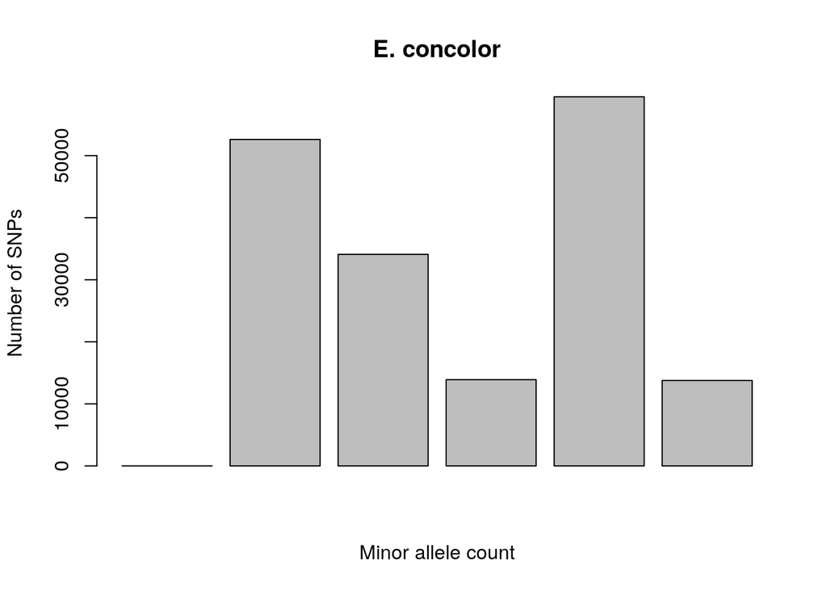

```r
concolor.sfs <- scan('concolor.sfs')
europaeus.sfs <- scan('europaeus.sfs')
roumanicus.sfs <- scan('roumanicus.sfs')
barplot(concolor.sfs[1:((length(concolor.sfs) - 1) / 2)],
        main = 'E. concolor', xlab = 'Minor allele count',
        ylab = 'Number of SNPs')
```

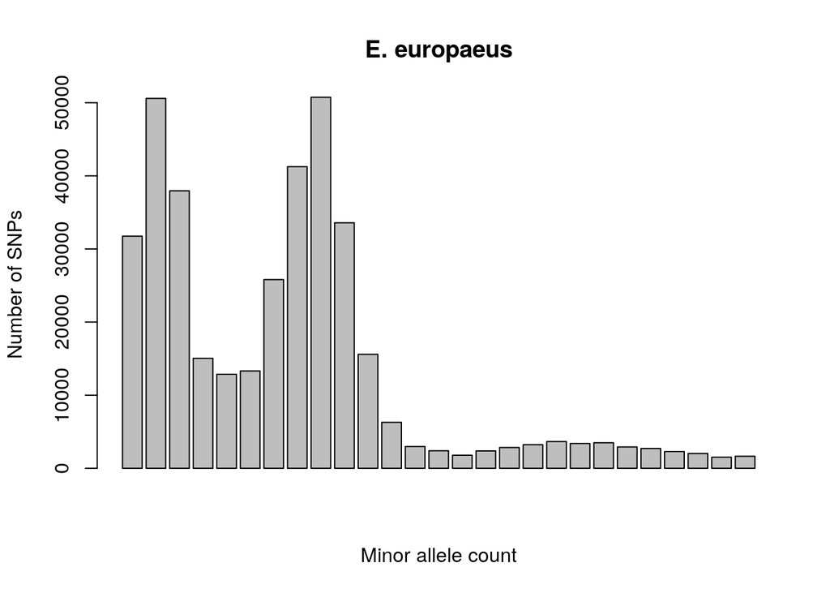

```r
barplot(europaeus.sfs[1:((length(europaeus.sfs) - 1) / 2)],
        main = 'E. europaeus', xlab = 'Minor allele count',
        ylab = 'Number of SNPs')
```

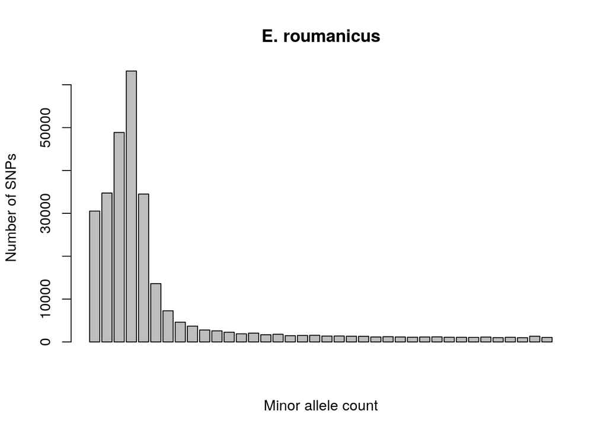

```r
barplot(roumanicus.sfs[1:((length(roumanicus.sfs) - 1)/ 2)],
        main = 'E. roumanicus', xlab = 'Minor allele count',
        ylab = 'Number of SNPs')
```

In the case of *E. europaeus*, the SFS is intriguing. The second peak is a huge excess of intermediate frequency SNPs. I suppose it could be caused by the presence of the two lineages.

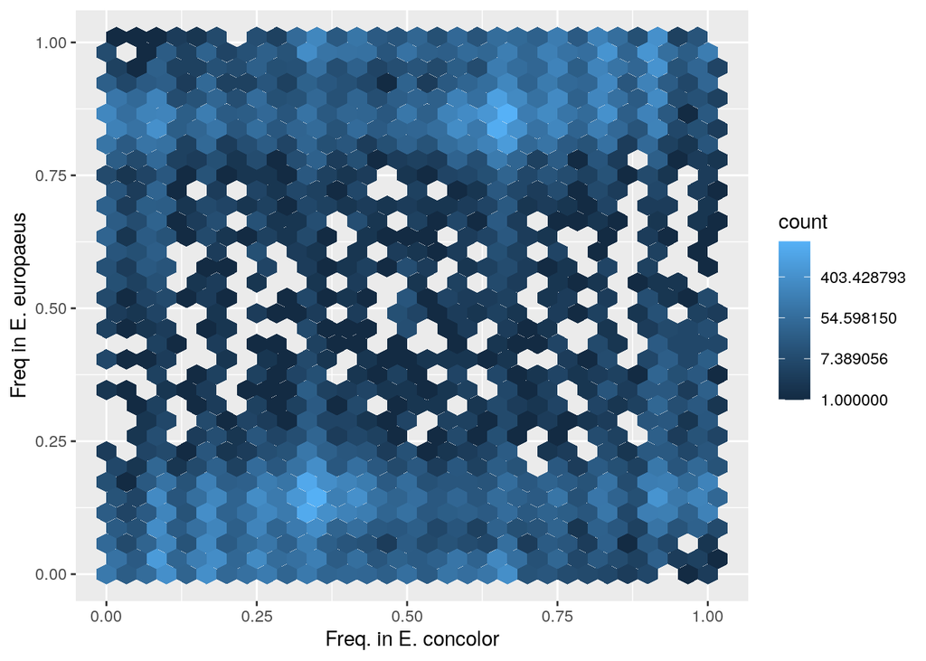

```r
library(ggplot2)
concolor.mafs   <- read.table('concolor.mafs',   header = TRUE, as.is = TRUE)
europaeus.mafs  <- read.table('europaeus.mafs',  header = TRUE, as.is = TRUE)
roumanicus.mafs <- read.table('roumanicus.mafs', header = TRUE, as.is = TRUE)
row.names(concolor.mafs)   <- paste(concolor.mafs$chromo,
                                    concolor.mafs$position, sep = '_')
row.names(europaeus.mafs)  <- paste(europaeus.mafs$chromo,
                                    europaeus.mafs$position, sep = '_')
row.names(roumanicus.mafs) <- paste(roumanicus.mafs$chromo,
                                    roumanicus.mafs$position, sep = '_')
concolor.mafs$first  <- pmin(concolor.mafs$major, concolor.mafs$minor)  # alphabetically first
concolor.mafs$second <- pmax(concolor.mafs$major, concolor.mafs$minor)  # alphabetically second
stopifnot(max(concolor.mafs$knownEM) <= 0.5)  # knownEM is the minor allele freq.
concolor.mafs$firstFreq <- sapply(1:dim(concolor.mafs)[1], function(x) {
  ifelse(concolor.mafs[x, 'minor'] < concolor.mafs[x, 'major'],
         concolor.mafs[x, 'knownEM'], 1.0 - concolor.mafs[x, 'knownEM'])
})

europaeus.mafs$first  <- pmin(europaeus.mafs$major, europaeus.mafs$minor)
europaeus.mafs$second <- pmax(europaeus.mafs$major, europaeus.mafs$minor)
stopifnot(max(europaeus.mafs$knownEM) <= 0.5)
europaeus.mafs$firstFreq <- sapply(1:dim(europaeus.mafs)[1], function(x) {
  ifelse(europaeus.mafs[x, 'minor'] < europaeus.mafs[x, 'major'],
         europaeus.mafs[x, 'knownEM'], 1.0 - europaeus.mafs[x, 'knownEM'])
})

roumanicus.mafs$first  <- pmin(roumanicus.mafs$major, roumanicus.mafs$minor)
roumanicus.mafs$second <- pmax(roumanicus.mafs$major, roumanicus.mafs$minor)
stopifnot(max(roumanicus.mafs$knownEM) <= 0.5)
roumanicus.mafs$firstFreq <- sapply(1:dim(roumanicus.mafs)[1], function(x) {
  ifelse(roumanicus.mafs[x, 'minor'] < roumanicus.mafs[x, 'major'],
         roumanicus.mafs[x, 'knownEM'], 1.0 - roumanicus.mafs[x, 'knownEM'])
})
common.ce <- intersect(row.names(concolor.mafs),
                       row.names(europaeus.mafs))
ce.mafs <- data.frame(
  c.first     = concolor.mafs[common.ce, 'first'],
  c.second    = concolor.mafs[common.ce, 'second'],
  c.firstFreq = concolor.mafs[common.ce, 'firstFreq'],
  e.first     = europaeus.mafs[common.ce, 'first'],
  e.second    = europaeus.mafs[common.ce, 'second'],
  e.firstFreq = europaeus.mafs[common.ce, 'firstFreq'],
  sameAlleles = concolor.mafs[common.ce, 'first'] == europaeus.mafs[common.ce, 'first'] &
                concolor.mafs[common.ce, 'second'] == europaeus.mafs[common.ce, 'second']
)

common.er <- intersect(row.names(europaeus.mafs),
                       row.names(roumanicus.mafs))
er.mafs <- data.frame(
  e.first     = europaeus.mafs[common.er, 'first'],
  e.second    = europaeus.mafs[common.er, 'second'],
  e.firstFreq = europaeus.mafs[common.er, 'firstFreq'],
  r.first     = roumanicus.mafs[common.er, 'first'],
  r.second    = roumanicus.mafs[common.er, 'second'],
  r.firstFreq = roumanicus.mafs[common.er, 'firstFreq'],
  sameAlleles = europaeus.mafs[common.er, 'first']  == roumanicus.mafs[common.er, 'first'] &&
                europaeus.mafs[common.er, 'second'] == roumanicus.mafs[common.er, 'second']
)

common.cr <- intersect(row.names(concolor.mafs),
                       row.names(roumanicus.mafs))
cr.mafs <- data.frame(
  c.first     = concolor.mafs[common.cr, 'first'],
  c.second    = concolor.mafs[common.cr, 'second'],
  c.firstFreq = concolor.mafs[common.cr, 'firstFreq'],
  r.first     = roumanicus.mafs[common.cr, 'first'],
  r.second    = roumanicus.mafs[common.cr, 'second'],
  r.firstFreq = roumanicus.mafs[common.cr, 'firstFreq'],
  sameAlleles = concolor.mafs[common.cr, 'first']  == roumanicus.mafs[common.cr, 'first'] &&
                concolor.mafs[common.cr, 'second'] == roumanicus.mafs[common.cr, 'second']
)

ggplot(data = ce.mafs[ce.mafs$sameAlleles, ], mapping = aes(x = c.firstFreq, y = e.firstFreq)) +
  geom_hex() + scale_fill_gradient(trans = 'log') +
  xlab('Freq. in E. concolor') + ylab('Freq in E. europaeus')
```

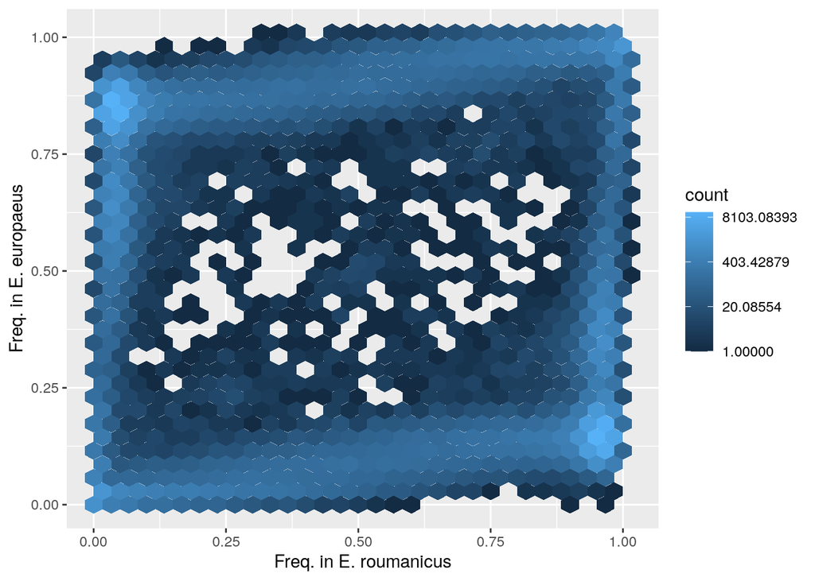

```r
ggplot(data = er.mafs[er.mafs$sameAlleles, ], mapping = aes(x = r.firstFreq, y = e.firstFreq)) +
  geom_hex() + scale_fill_gradient(trans = 'log') +
  xlab('Freq. in E. roumanicus') + ylab('Freq. in E. europaeus')
```

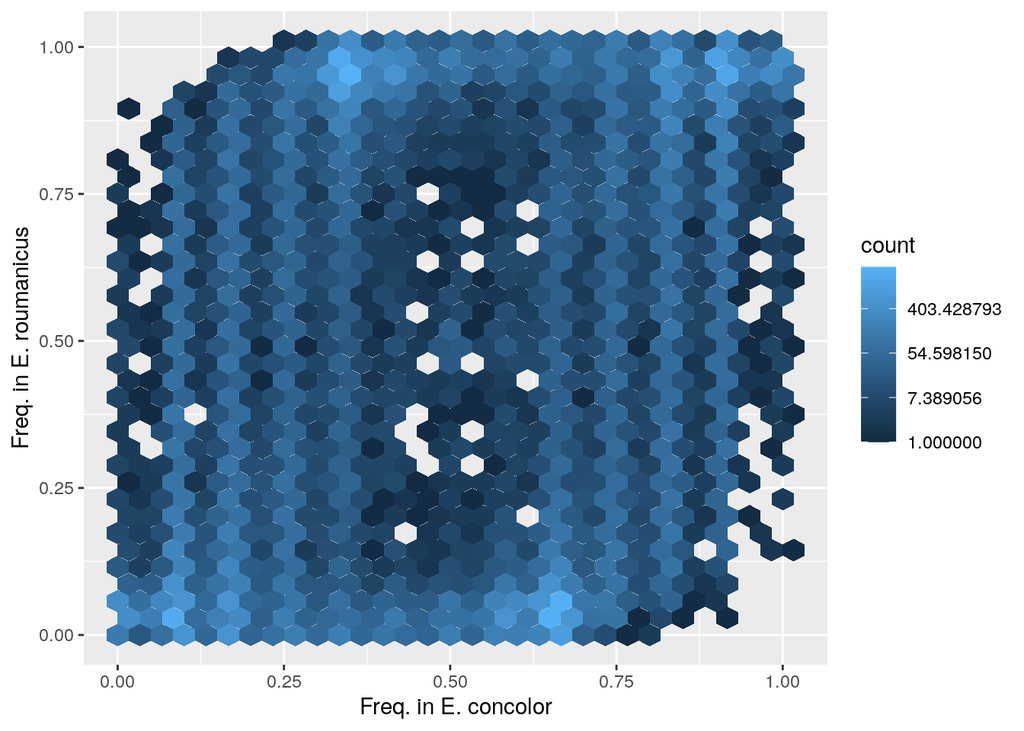

```r
ggplot(data = cr.mafs[cr.mafs$sameAlleles, ], mapping = aes(x = c.firstFreq, y = r.firstFreq)) +
  geom_hex() + scale_fill_gradient(trans = 'log') +
  xlab('Freq. in E. concolor') + ylab('Freq. in E. roumanicus')
```

One difficulty to interprete the plots above is that they compare the frequency of the alphabetically first allele between species. That was easier than guessing the ancestral one. But, I will probably have to infer the ancestral alleles and unfold the SFS. Next folder.

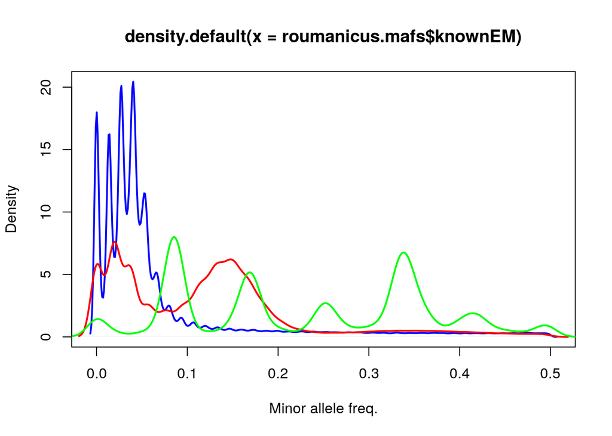

```r
plot(density(roumanicus.mafs$knownEM), col = 'blue', lwd = 2, xlab = 'Minor allele freq.')
lines(density(europaeus.mafs$knownEM), col = 'red',  lwd = 2)
lines(density(concolor.mafs$knownEM), col = 'green', lwd = 2)
```

The smoothed densities of minor allele frequencies resemble the respective SFSs, but are not accurate. Just for comparison.

## References

Nielsen, Thorfinn AND Albrechtsen, Rasmus AND Korneliussen. 2012. “SNP Calling, Genotype Calling, and Sample Allele Frequency Estimation from New-Generation Sequencing Data.” *PLoS ONE* 7 (7): 1–10. https://doi.org/10.1371/journal.pone.0037558.